# Comparison escapees vs non-escapees - Hsu et al.

# 1. Data loading and fast exploration by PCA

Loading bsseq objects

```r
bsseq_obj_escapees <- readRDS(paste0(params$InputFolder, "bsseq_obj_escapees_Hsu.rds"))
bsseq_obj_NonEscapees <- readRDS(paste0(params$InputFolder, "bsseq_obj_NonEscapees_Hsu.rds"))
```

- 302502 CpG loci belong to escapees regions (escapee CpGs).
- 27513050 CpG loci do not belong to escapees regions (non-escapee CpGs).

**Colors for figures**

```r
cellTypes_colors <- c(hESC ="#dd1c77", D4hPGCLC ="#4daf4a")
```

## PCA only on escapee CpGs - For now focus on WGBS

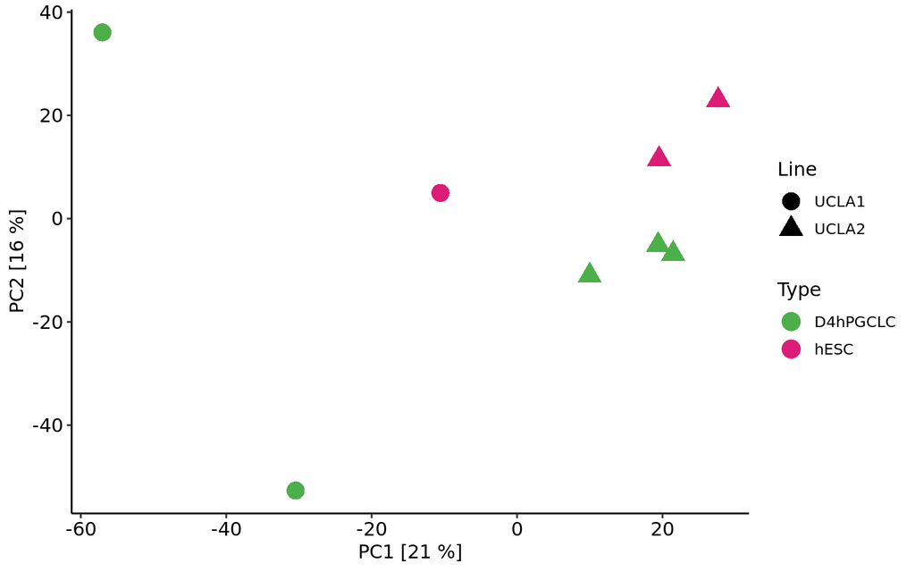

```r
pca_res <- do_PCA(assays(bsseq_obj_escapees)$Meth_WGBS)
sample_anno <- bsseq::pData(bsseq_obj_escapees)
plot_PCA(pca_res = pca_res, anno = sample_anno, col_anno = "Type", shape_anno = "Line", custom_colors = cellTypes_colors, point_size = 5)
```

## PCA only on non-escapee CpGs

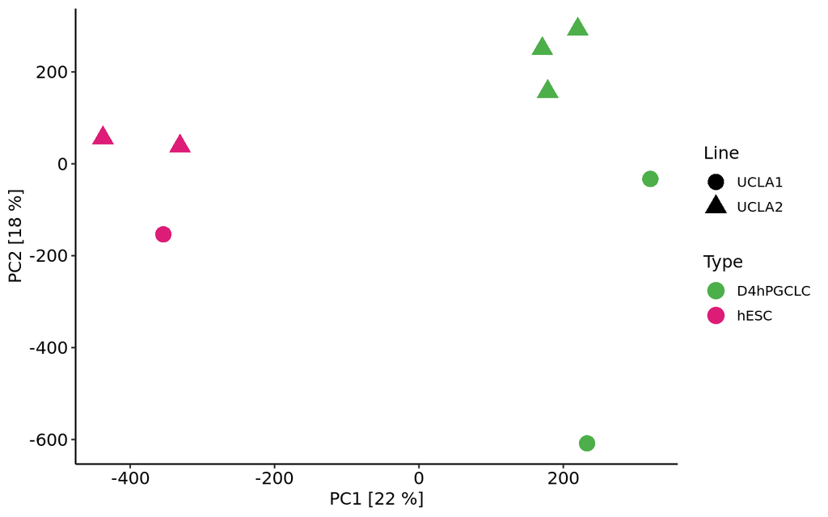

```r
pca_res <- do_PCA(assays(bsseq_obj_NonEscapees)$Meth_WGBS)
sample_anno <- bsseq::pData(bsseq_obj_NonEscapees)
plot_PCA(pca_res = pca_res, anno = sample_anno, col_anno = "Type", shape_anno = "Line", custom_colors = cellTypes_colors, point_size = 5)
```

# 2.Generation of 500 random sets of 302502 non-escapee CpGs and distributions plots

Let’s generate random indices to randomly select 302502 CpG loci among the non-escapee ones.

```r
random_sets <- list()

for (i in 1:num_permutations) {
  random_indices <- sample(1:dim(bsseq_obj_NonEscapees)[1], dim(bsseq_obj_escapees)[1], replace = FALSE)
  bsseq_obj_randomNonEscapees <- bsseq_obj_NonEscapees[random_indices, ]

  random_sets[[i]] <- bsseq_obj_randomNonEscapees
}
```

**Head of BSSEQ with escapee CpGs**

```r
assays(bsseq_obj_escapees)$Meth_WGBS %>% head()
```

```
##      UCLA1_hESC_rep3 UCLA1_D4hPGCLC_rep2 UCLA1_D4hPGCLC_rep3 UCLA2_hESC_rep2
## [1,]       0.8750000                0.80           1.0000000       1.0000000
## [2,]       1.0000000                1.00           1.0000000       1.0000000
## [3,]       1.0000000                0.40           1.0000000       1.0000000
## [4,]       0.9090909                1.00           1.0000000       0.8333333
## [5,]       1.0000000                0.75           1.0000000       0.7777778
## [6,]       1.0000000                1.00           0.9166667       0.9166667
##      UCLA2_hESC_rep3 UCLA2_D4hPGCLC_rep1 UCLA2_D4hPGCLC_rep2
## [1,]       0.8571429           1.0000000                 1.0
## [2,]       1.0000000           1.0000000                 1.0
## [3,]       0.8888889           0.7272727                 1.0
## [4,]       0.7777778           0.8000000                 1.0
## [5,]       0.8125000           1.0000000                 0.8
## [6,]       0.8125000           0.8125000                 1.0
##      UCLA2_D4hPGCLC_rep3
## [1,]           0.8888889
## [2,]           0.8888889
## [3,]           1.0000000
## [4,]           0.8888889
## [5,]           1.0000000
## [6,]           1.0000000
```

**Escapee CpG methylation distribution plot**

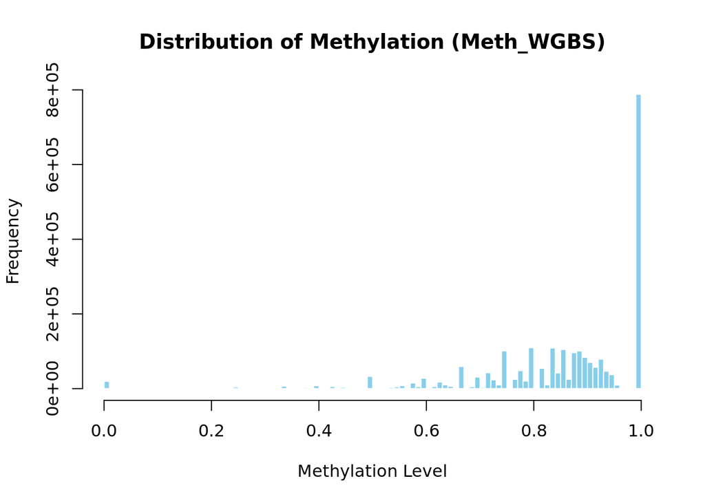

```r
hist(assays(bsseq_obj_escapees)$Meth_WGB, breaks = 100, main = "Distribution of Methylation (Meth_WGBS)",
     xlab = "Methylation Level", col = "skyblue", border = "white")
```

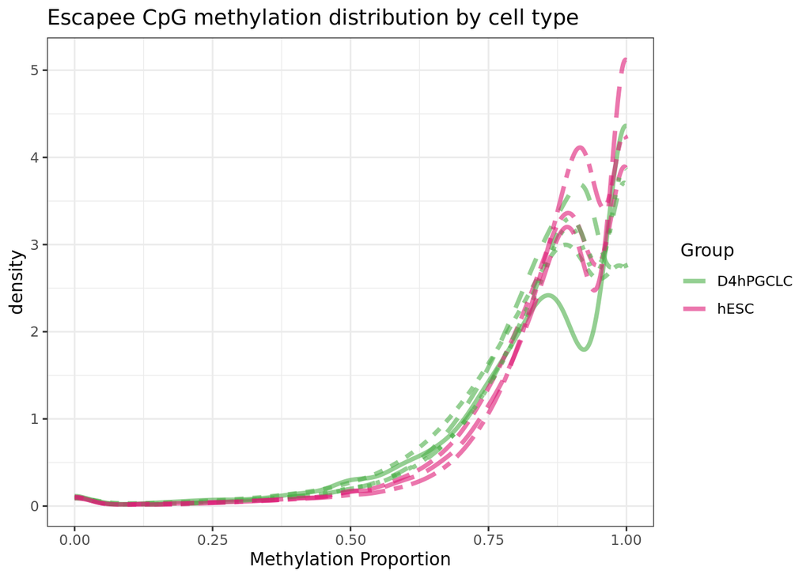

```r
assays(bsseq_obj_escapees)$M <- assays(bsseq_obj_escapees)$M_WGBS
assays(bsseq_obj_escapees)$Cov <- assays(bsseq_obj_escapees)$Cov_WGBS
plotEmpiricalDistribution(bsseq_obj_escapees,
                          bySample = TRUE,
                          testCovariate = "Type",
                          adj = 3) + guides(linetype="none") +
  labs(title = "Escapee CpG methylation distribution by cell type") + ggplot2::scale_color_manual(values = cellTypes_colors)
```

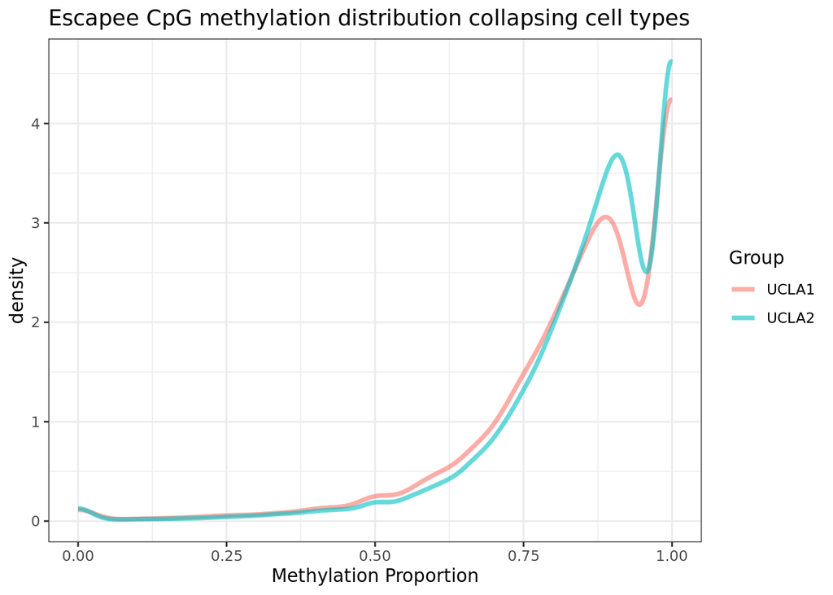

```r
plotEmpiricalDistribution(bsseq_obj_escapees,
                          bySample = FALSE,
                          testCovariate = "Line",
                          adj = 3) + guides(linetype="none") +
  labs(title = "Escapee CpG methylation distribution collapsing cell types")
```

**Non-Escapee CpG methylation distribution plot**

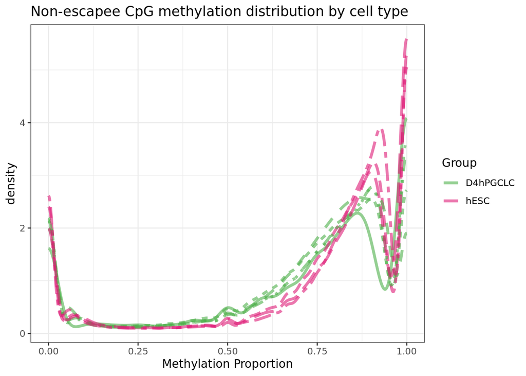

```r
assays(bsseq_obj_NonEscapees)$M <- assays(bsseq_obj_NonEscapees)$M_WGBS
assays(bsseq_obj_NonEscapees)$Cov <- assays(bsseq_obj_NonEscapees)$Cov_WGBS
plotEmpiricalDistribution(bsseq_obj_NonEscapees,
                          bySample = TRUE,
                          testCovariate = "Type",
                          adj = 3) + guides(linetype="none") +
  labs(title = "Non-escapee CpG methylation distribution by cell type") + ggplot2::scale_color_manual(values = cellTypes_colors)
```

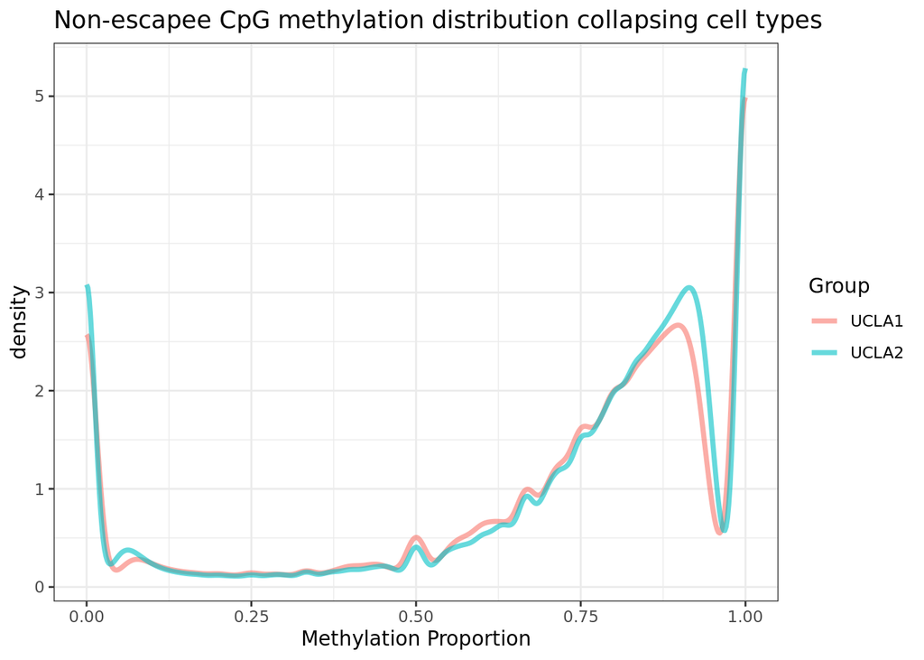

```r
plotEmpiricalDistribution(bsseq_obj_NonEscapees,
                          bySample = FALSE,
                          testCovariate = "Line",
                          adj = 3) + guides(linetype="none") +
  labs(title = "Non-escapee CpG methylation distribution collapsing cell types")
```

**Head of first BSSEQ with randomly selected non-escapee CpGs**

```r
assays(random_sets[[1]])$Meth_WGBS %>% head()
```

```
##      UCLA1_hESC_rep3 UCLA1_D4hPGCLC_rep2 UCLA1_D4hPGCLC_rep3 UCLA2_hESC_rep2
## [1,]       1.0000000           0.6000000           0.8000000       0.9333333
## [2,]       0.8947368           0.7500000           0.8181818       0.9166667
## [3,]       1.0000000           0.8750000           1.0000000       0.8571429
## [4,]       0.8235294           0.1666667           0.1428571       0.7142857
## [5,]       0.9000000           0.6000000           0.6666667       0.8461538
## [6,]       0.1000000           0.0000000           0.0000000       0.0000000
##      UCLA2_hESC_rep3 UCLA2_D4hPGCLC_rep1 UCLA2_D4hPGCLC_rep2
## [1,]       1.0000000           0.9310345           0.9166667
## [2,]       0.6666667           0.8421053           1.0000000
## [3,]       0.9090909           0.9444444           1.0000000
## [4,]       0.6875000           0.2500000           0.4375000
## [5,]       0.8333333           0.7727273           0.6666667
## [6,]       0.0000000           0.0000000           0.0000000
##      UCLA2_D4hPGCLC_rep3
## [1,]           0.8750000
## [2,]           1.0000000
## [3,]           0.9285714
## [4,]           0.2222222
## [5,]           0.8571429
## [6,]           0.0000000
```

**First set of randomly selected non-escapee CpG methylation distribution plot**

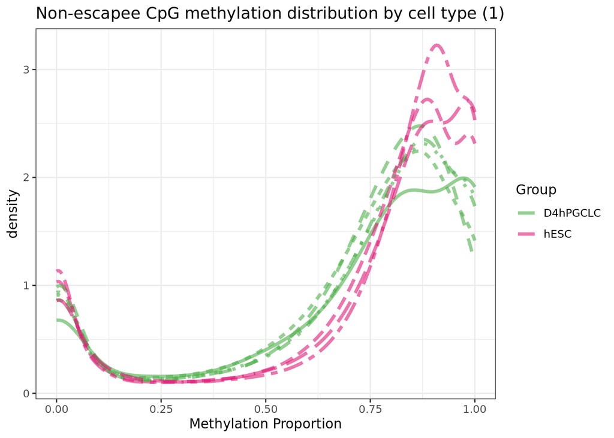

```r
assays(random_sets[[1]])$M <- assays(random_sets[[1]])$M_WGBS
assays(random_sets[[1]])$Cov <- assays(random_sets[[1]])$Cov_WGBS
plotEmpiricalDistribution(random_sets[[1]],
                          bySample = TRUE,
                          testCovariate = "Type",
                          adj = 3) + guides(linetype="none") +
  labs(title = "Non-escapee CpG methylation distribution by cell type (1)") + ggplot2::scale_color_manual(values = cellTypes_colors)
```

**Head of second BSSEQ with randomly selected non-escapee CpGs**

```r
assays(random_sets[[2]])$Meth_WGBS %>% head()
```

```
##      UCLA1_hESC_rep3 UCLA1_D4hPGCLC_rep2 UCLA1_D4hPGCLC_rep3 UCLA2_hESC_rep2
## [1,]       0.8000000           0.7500000           0.6666667       1.0000000
## [2,]       0.6250000           0.6250000           0.5833333       1.0000000
## [3,]       0.8571429           0.8000000           0.8000000       0.9333333
## [4,]       0.9230769           0.5714286           0.7142857       0.6666667
## [5,]       0.8571429           1.0000000           0.8333333       0.8000000
## [6,]       0.5000000           1.0000000           0.7142857       1.0000000
##      UCLA2_hESC_rep3 UCLA2_D4hPGCLC_rep1 UCLA2_D4hPGCLC_rep2
## [1,]       0.8750000           0.7142857           0.7500000
## [2,]       0.6666667           0.5714286           0.5555556
## [3,]       0.9166667           0.8800000           0.9230769
## [4,]       0.6250000           0.4545455           0.2500000
## [5,]       0.8000000           1.0000000           1.0000000
## [6,]       0.9687500           0.9000000           1.0000000
##      UCLA2_D4hPGCLC_rep3
## [1,]           0.8000000
## [2,]           0.7500000
## [3,]           0.7857143
## [4,]           0.6153846
## [5,]           0.7500000
## [6,]           0.8571429
```

**Second set of randomly selected non-escapee CpG methylation distribution plot**

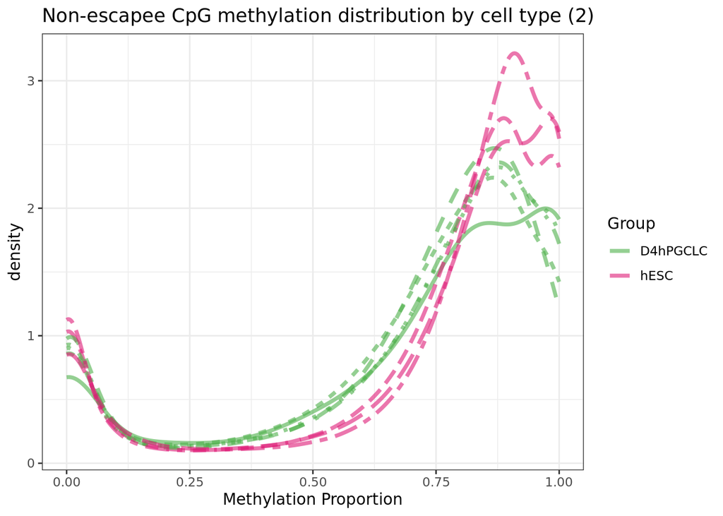

```r
assays(random_sets[[2]])$M <- assays(random_sets[[2]])$M_WGBS
assays(random_sets[[2]])$Cov <- assays(random_sets[[2]])$Cov_WGBS
plotEmpiricalDistribution(random_sets[[2]],
                          bySample = TRUE,
                          testCovariate = "Type",
                          adj = 3) + guides(linetype="none") +
  labs(title = "Non-escapee CpG methylation distribution by cell type (2)") + ggplot2::scale_color_manual(values = cellTypes_colors)
```

# 3. Kolmogorov-Smirnov test

Example of KS test result comparing distributions in case of UCLA1_hESC_rep3 sample: escapee CpG methylation levels vs first randomly selected non-escapee set.

```r
ks_test_result <- ks.test(assays(bsseq_obj_escapees)$Meth_WGBS[, "UCLA1_hESC_rep3"], assays(random_sets[[1]])$Meth_WGBS[, "UCLA1_hESC_rep3"])
print(ks_test_result)
```

```
##
##  Asymptotic two-sample Kolmogorov-Smirnov test
##
## data:  assays(bsseq_obj_escapees)$Meth_WGBS[, "UCLA1_hESC_rep3"] and assays(random_sets[[1]])$Meth_WGBS[, "UCLA1_hESC_rep3"]
## D = 0.14213, p-value < 2.2e-16
## alternative hypothesis: two-sided
```

Example of KS test result comparing distributions in case of UCLA1_hESC_rep3 sample: first randomly selected non-escapee set vs second randomly selected non-escapee set.

```r
ks_test_result <- ks.test(assays(random_sets[[1]])$Meth_WGBS[, "UCLA1_hESC_rep3"], assays(random_sets[[2]])$Meth_WGBS[, "UCLA1_hESC_rep3"])
print(ks_test_result)
```

```
##
##  Asymptotic two-sample Kolmogorov-Smirnov test
##
## data:  assays(random_sets[[1]])$Meth_WGBS[, "UCLA1_hESC_rep3"] and assays(random_sets[[2]])$Meth_WGBS[, "UCLA1_hESC_rep3"]
## D = 0.0017454, p-value = 0.7461
## alternative hypothesis: two-sided
```

Example of KS test result comparing distributions: escapee CpG methylation levels (UCLA2_hESC_rep2 sample) vs first randomly selected non-escapee set (UCLA1_D4hPGCLC_rep3 sample).

```r
ks_test_result <- ks.test(assays(bsseq_obj_escapees)$Meth_WGBS[, "UCLA2_hESC_rep2"],  assays(random_sets[[1]])$Meth_WGBS[, "UCLA1_D4hPGCLC_rep3"])
print(ks_test_result)
```

```
##
##  Asymptotic two-sample Kolmogorov-Smirnov test
##
## data:  assays(bsseq_obj_escapees)$Meth_WGBS[, "UCLA2_hESC_rep2"] and assays(random_sets[[1]])$Meth_WGBS[, "UCLA1_D4hPGCLC_rep3"]
## D = 0.3007, p-value < 2.2e-16
## alternative hypothesis: two-sided
```

Example of KS test result comparing distributions: escapee CpG methylation levels vs first randomly selected non-escapee set **considering the mean levels across cell types (rowwise)**.

```r
ks_test_result <- ks.test(assays(bsseq_obj_escapees)$Meth_WGBS %>% rowMeans(na.rm = TRUE), assays(random_sets[[1]])$Meth_WGBS %>% rowMeans(na.rm = TRUE))
print(ks_test_result)
```

```
##
##  Asymptotic two-sample Kolmogorov-Smirnov test
##
## data:  assays(bsseq_obj_escapees)$Meth_WGBS %>% rowMeans(na.rm = TRUE) and assays(random_sets[[1]])$Meth_WGBS %>% rowMeans(na.rm = TRUE)
## D = 0.2318, p-value < 2.2e-16
## alternative hypothesis: two-sided
```

Example of KS test result comparing distributions: first randomly selected non-escapee set vs second randomly selected non-escapee set **considering the mean levels across cell types (rowwise)**.

```r
ks_test_result <- ks.test(assays(random_sets[[1]])$Meth_WGBS %>% rowMeans(na.rm = TRUE), assays(random_sets[[2]])$Meth_WGBS %>% rowMeans(na.rm = TRUE))
print(ks_test_result)
```

```
##
##  Asymptotic two-sample Kolmogorov-Smirnov test
##
## data:  assays(random_sets[[1]])$Meth_WGBS %>% rowMeans(na.rm = TRUE) and assays(random_sets[[2]])$Meth_WGBS %>% rowMeans(na.rm = TRUE)
## D = 0.0024463, p-value = 0.3258
## alternative hypothesis: two-sided
```

*Let’s calculate the mean methylation levels across cell types in all sets of randomly selected non-escapee CpGs.*

```r
random_MeanMethLevels <- lapply(random_sets, function(bsseq){
  assays(bsseq)$Meth_WGBS %>% rowMeans(na.rm = TRUE)})
```

**Let’s do KS test comparing escapee CpG methylation levels vs all 500 randomly selected non-escapee sets.**

```r
ks_test_results <- lapply(random_MeanMethLevels, function(random_MeanMeth) {
  ks.test(assays(bsseq_obj_escapees)$Meth_WGBS %>% rowMeans(na.rm = TRUE), random_MeanMeth)
})
pvalues_kstest <- sapply(ks_test_results, function(result) {
  result$p.value
})
adjusted_pvalues_kstest <- p.adjust(pvalues_kstest, method = "fdr")
print(adjusted_pvalues_kstest)
```

```
##   [1] 0 0 0 0 0 0 0 0 0 0 0 0 0 0 0 0 0 0 0 0 0 0 0 0 0 0 0 0 0 0 0 0 0 0 0 0 0
##  [38] 0 0 0 0 0 0 0 0 0 0 0 0 0 0 0 0 0 0 0 0 0 0 0 0 0 0 0 0 0 0 0 0 0 0 0 0 0
##  [75] 0 0 0 0 0 0 0 0 0 0 0 0 0 0 0 0 0 0 0 0 0 0 0 0 0 0 0 0 0 0 0 0 0 0 0 0 0
## [112] 0 0 0 0 0 0 0 0 0 0 0 0 0 0 0 0 0 0 0 0 0 0 0 0 0 0 0 0 0 0 0 0 0 0 0 0 0
## [149] 0 0 0 0 0 0 0 0 0 0 0 0 0 0 0 0 0 0 0 0 0 0 0 0 0 0 0 0 0 0 0 0 0 0 0 0 0
## [186] 0 0 0 0 0 0 0 0 0 0 0 0 0 0 0 0 0 0 0 0 0 0 0 0 0 0 0 0 0 0 0 0 0 0 0 0 0
## [223] 0 0 0 0 0 0 0 0 0 0 0 0 0 0 0 0 0 0 0 0 0 0 0 0 0 0 0 0 0 0 0 0 0 0 0 0 0
## [260] 0 0 0 0 0 0 0 0 0 0 0 0 0 0 0 0 0 0 0 0 0 0 0 0 0 0 0 0 0 0 0 0 0 0 0 0 0
## [297] 0 0 0 0 0 0 0 0 0 0 0 0 0 0 0 0 0 0 0 0 0 0 0 0 0 0 0 0 0 0 0 0 0 0 0 0 0
## [334] 0 0 0 0 0 0 0 0 0 0 0 0 0 0 0 0 0 0 0 0 0 0 0 0 0 0 0 0 0 0 0 0 0 0 0 0 0
## [371] 0 0 0 0 0 0 0 0 0 0 0 0 0 0 0 0 0 0 0 0 0 0 0 0 0 0 0 0 0 0 0 0 0 0 0 0 0
## [408] 0 0 0 0 0 0 0 0 0 0 0 0 0 0 0 0 0 0 0 0 0 0 0 0 0 0 0 0 0 0 0 0 0 0 0 0 0
## [445] 0 0 0 0 0 0 0 0 0 0 0 0 0 0 0 0 0 0 0 0 0 0 0 0 0 0 0 0 0 0 0 0 0 0 0 0 0
## [482] 0 0 0 0 0 0 0 0 0 0 0 0 0 0 0 0 0 0 0
```

How many adjusted p-values are < 0.05?

```r
table(adjusted_pvalues_kstest < 0.05)
```

```
##
## TRUE
##  500
```

**Let’s do KS test comparing first randomly selected non-escapee set vs all 500 randomly selected non-escapee sets.**

```r
ks_test_results <- lapply(random_MeanMethLevels, function(random_MeanMeth) {
  ks.test(random_MeanMethLevels[[1]], random_MeanMeth)
})
pvalues_kstest <- sapply(ks_test_results, function(result) {
  result$p.value
})
adjusted_pvalues_kstest <- p.adjust(pvalues_kstest, method = "fdr")
print(adjusted_pvalues_kstest)
```

```
##   [1] 1.0000000 0.8387421 0.9800503 0.8210148 0.9715843 0.8210148 0.9940842
##   [8] 0.9887370 0.8210148 0.8210148 0.8210148 0.9940842 0.8210148 0.9285689
##  [15] 0.8210148 0.9800503 0.8210148 0.8210148 0.8210148 0.9940842 0.9940842
##  [22] 0.9715843 0.8210148 0.8210148 0.9715843 0.9285689 0.8210148 0.9800503
##  [29] 0.8210148 0.9800503 0.9800503 0.8210148 0.8210148 0.9887370 0.8654371
##  [36] 0.8210148 0.9800503 0.8210148 0.9800503 0.9940842 0.8210148 0.8210148
##  [43] 0.8210148 0.9887370 0.9285689 0.9940842 0.8210148 0.8210148 0.9285689
##  [50] 0.9887370 0.9940842 0.9285689 0.9285689 0.9100922 0.9940842 0.9800503
##  [57] 0.9800503 0.8210148 0.8210148 0.9531270 0.9889643 0.9889643 0.9336101
##  [64] 0.9940842 0.9940842 0.9800503 0.8210148 0.9940842 0.8210148 0.9887370
##  [71] 0.9940842 0.8210148 0.9940842 0.8210148 0.8210148 0.9940842 0.9940842
##  [78] 0.8210148 0.8210148 0.8210148 0.8210148 0.9887370 0.9672040 0.9285689
##  [85] 0.8210148 0.9940842 0.8210148 0.9285689 0.9800503 0.9800503 0.8210148
##  [92] 0.8210148 0.9800503 0.9285689 0.9940842 0.8210148 0.9940842 0.9940842
##  [99] 0.9800503 0.9940842 0.9889643 0.9940842 0.9887370 0.9940842 0.8210148
```

[output cut: 57 more lines]

How many adjusted p-values are < 0.05?

```r
table(adjusted_pvalues_kstest < 0.05)
```

```
##
## FALSE
##   500
```

# 4.Escapee and non escapee CpG methylation distribution plot

## 4.1 WGBS Meth

```r
MeanMethLevels_df <- c(unlist(random_MeanMethLevels), assays(bsseq_obj_escapees)$Meth_WGBS %>% rowMeans(na.rm = TRUE) %>% as.vector()) %>% as.data.frame()
colnames(MeanMethLevels_df) <- "MeanMeth"
MeanMethLevels_df$Distribution <- c(paste0("Random_", rep(1:num_permutations, each = dim(bsseq_obj_escapees)[1])), rep("Escapees_CpGs", each = dim(bsseq_obj_escapees)[1]))
MeanMethLevels_df$Category <- "Non Escapees"
MeanMethLevels_df$Category[(nrow(MeanMethLevels_df)+1-nrow(bsseq_obj_escapees)):nrow(MeanMethLevels_df)] <- "Escapees"
```

### Mean methylation levels collapsing cell types

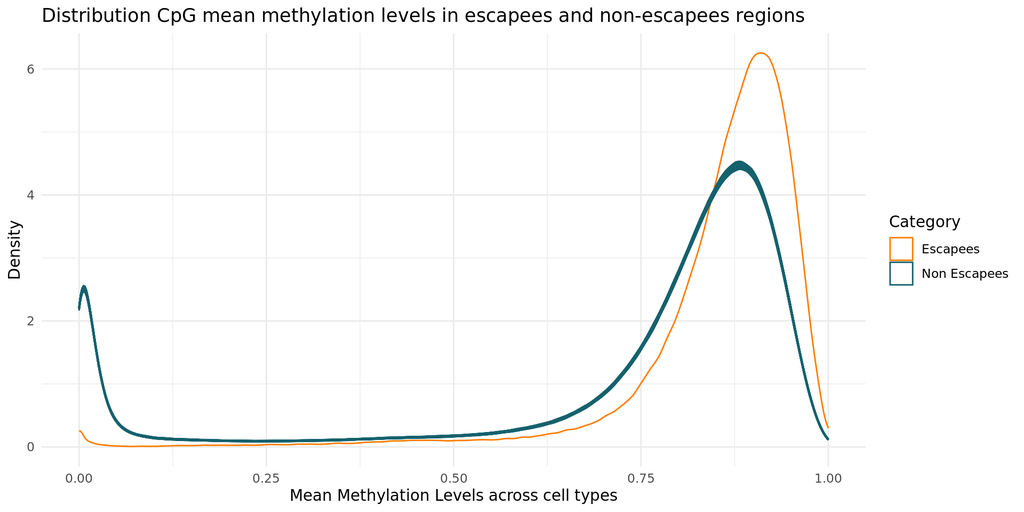

```r
ggplot(MeanMethLevels_df, aes(x = MeanMeth, color = Category, group = Distribution)) +
  geom_density(alpha = 0.5)  +
  labs(
    title = "Distribution CpG mean methylation levels in escapees and non-escapees regions",
    x = "Mean Methylation Levels across cell types",
    y = "Density",
    color = "Category"
  ) +
  scale_color_manual(values = c("Escapees" = "#FF7D00", "Non Escapees" = "#15616D")) +
  theme_minimal()
```

### Mean methylation levels separating cell types

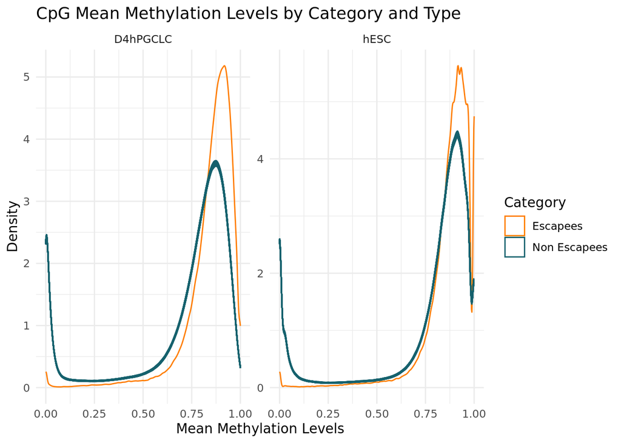

```r
# Define function to compute rowMeans for specific sample types
get_rowMeans_by_type <- function(bsseq, type_label) {
  sample_indices <- which(colData(bsseq)$Type == type_label)
  rowMeans(assays(bsseq)$Meth_WGBS[, sample_indices, drop = FALSE], na.rm = TRUE)
}

# Apply the function to each random set for both hESC and D4hPGCLC
random_MeanMethLevels_hESC <- lapply(random_sets, get_rowMeans_by_type, type_label = "hESC")
random_MeanMethLevels_D4hPGCLC <- lapply(random_sets, get_rowMeans_by_type, type_label = "D4hPGCLC")

# Do the same for escapees
escapees_MeanMeth_hESC <- get_rowMeans_by_type(bsseq_obj_escapees, "hESC")
escapees_MeanMeth_D4hPGCLC <- get_rowMeans_by_type(bsseq_obj_escapees, "D4hPGCLC")

# Combine all into a single data frame
MeanMethLevels_df <- data.frame(
  MeanMeth = c(
    unlist(random_MeanMethLevels_hESC),
    unlist(random_MeanMethLevels_D4hPGCLC),
    escapees_MeanMeth_hESC,
    escapees_MeanMeth_D4hPGCLC
  ),
  Distribution = c(
    paste0("Random_hESC_", rep(1:num_permutations, each = dim(bsseq_obj_escapees)[1])),
    paste0("Random_D4hPGCLC_", rep(1:num_permutations, each = dim(bsseq_obj_escapees)[1])),
    rep("Escapees_hESC", each = dim(bsseq_obj_escapees)[1]),
    rep("Escapees_D4hPGCLC", each = dim(bsseq_obj_escapees)[1])
  ),
  Category = c(
    rep("Non Escapees", 2 * num_permutations * dim(bsseq_obj_escapees)[1]),
    rep("Escapees", 2 * dim(bsseq_obj_escapees)[1])
  ),
  Type = c(
    rep("hESC", num_permutations * dim(bsseq_obj_escapees)[1]),
    rep("D4hPGCLC", num_permutations * dim(bsseq_obj_escapees)[1]),
    rep("hESC", dim(bsseq_obj_escapees)[1]),
    rep("D4hPGCLC", dim(bsseq_obj_escapees)[1])
  )
)

ggplot(MeanMethLevels_df, aes(x = MeanMeth, color = Category, group = Distribution)) +
  geom_density(alpha = 0.5)  +
  labs(
    title = "CpG Mean Methylation Levels by Category and Type",
    x = "Mean Methylation Levels",
    y = "Density",
    color = "Category"
  ) +
  facet_wrap(~ Type, scales = "free_y") +
  scale_color_manual(values = c("Escapees" = "#FF7D00", "Non Escapees" = "#15616D")) +
  theme_minimal()
```

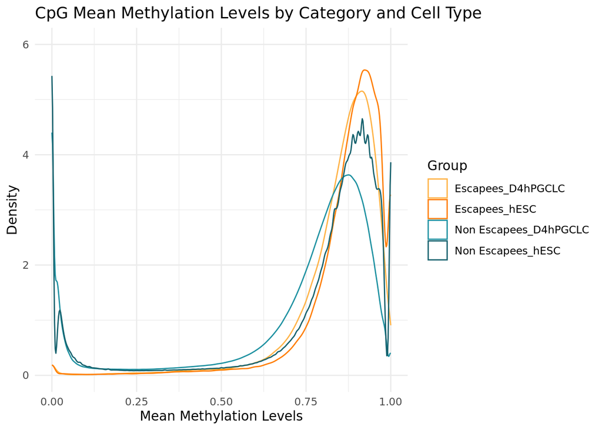

```r
# Create a new combined variable in the dataframe
MeanMethLevels_df$GroupLabel <- paste(MeanMethLevels_df$Category, MeanMethLevels_df$Type, sep = "_")

# Now plot using this combined label
ggplot(MeanMethLevels_df, aes(x = MeanMeth, color = GroupLabel, group = GroupLabel)) +
  geom_density(alpha = 0.6, adjust = 1.5) +  # smoother curves using `adjust`
  labs(
    title = "CpG Mean Methylation Levels by Category and Cell Type",
    x = "Mean Methylation Levels",
    y = "Density",
    color = "Group"
  ) +
  scale_color_manual(
    values = c(
      "Escapees_hESC" = "#FF7D00",
      "Escapees_D4hPGCLC" = "#FFB347",
      "Non Escapees_hESC" = "#15616D",
      "Non Escapees_D4hPGCLC" = "#1E91A1"
    )
  ) +
  coord_cartesian(ylim = c(0, 6)) +  # cut off at y = 6
  theme_minimal()
```

## 4.2 bACEseq Meth

```r
random_MeanHydroxyMethLevels <- lapply(random_sets, function(bsseq){
  assays(bsseq)$Meth_hmC %>% rowMeans(na.rm = TRUE)})
MeanHydroxyMethLevels_df <- c(unlist(random_MeanHydroxyMethLevels), assays(bsseq_obj_escapees)$Meth_hmC %>% rowMeans(na.rm = TRUE) %>% as.vector()) %>% as.data.frame()
colnames(MeanHydroxyMethLevels_df) <- "MeanHydroxyMeth"
MeanHydroxyMethLevels_df$Distribution <- c(paste0("Random_", rep(1:num_permutations, each = dim(bsseq_obj_escapees)[1])), rep("Escapees_CpGs", each = dim(bsseq_obj_escapees)[1]))
MeanHydroxyMethLevels_df$Category <- "Non Escapees"
MeanHydroxyMethLevels_df$Category[(nrow(MeanHydroxyMethLevels_df)+1-nrow(bsseq_obj_escapees)):nrow(MeanHydroxyMethLevels_df)] <- "Escapees"
```

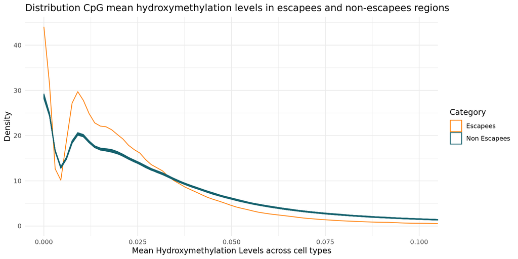

```r
ggplot(MeanHydroxyMethLevels_df, aes(x = MeanHydroxyMeth, color = Category, group = Distribution)) +
  geom_density(alpha = 0.5)  +
  labs(
    title = "Distribution CpG mean hydroxymethylation levels in escapees and non-escapees regions",
    x = "Mean Hydroxymethylation Levels across cell types",
    y = "Density",
    color = "Category"
  ) +
  scale_color_manual(values = c("Escapees" = "#FF7D00", "Non Escapees" = "#15616D"))  +
  coord_cartesian(xlim = c(0, 0.1)) +
  theme_minimal()
```

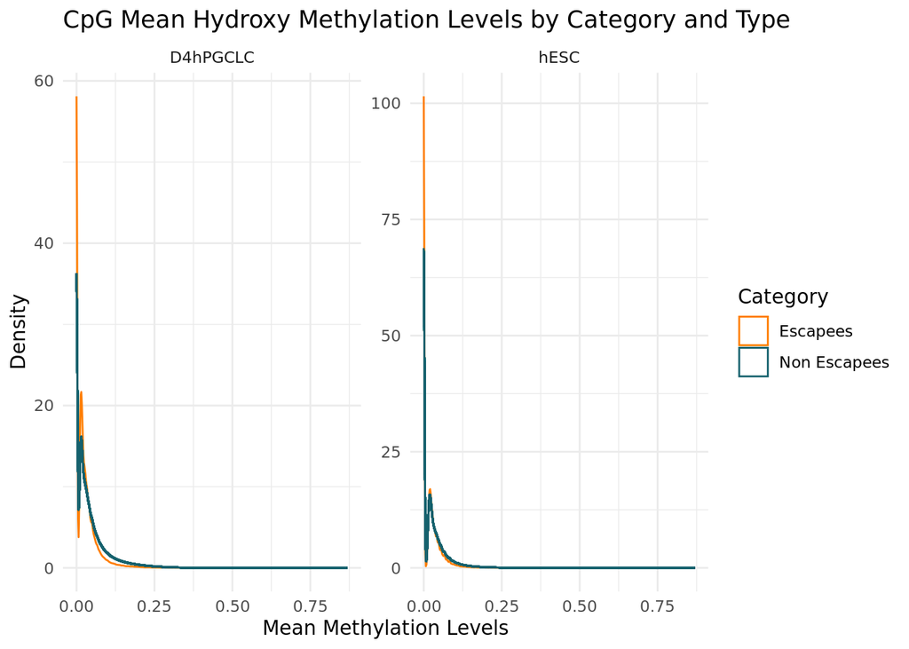

```r
# Define function to compute rowMeans for specific sample types
get_rowMeans_by_type_hydroxy <- function(bsseq, type_label) {
  sample_indices <- which(colData(bsseq)$Type == type_label)
  rowMeans(assays(bsseq)$Meth_hmC[, sample_indices, drop = FALSE], na.rm = TRUE)
}

# Apply the function to each random set for both hESC and D4hPGCLC
random_MeanHydroxyMethLevels_hESC <- lapply(random_sets, get_rowMeans_by_type_hydroxy, type_label = "hESC")
random_MeanHydroxyMethLevels_D4hPGCLC <- lapply(random_sets, get_rowMeans_by_type_hydroxy, type_label = "D4hPGCLC")

# Do the same for escapees
escapees_MeanHydroxyMeth_hESC <- get_rowMeans_by_type_hydroxy(bsseq_obj_escapees, "hESC")
escapees_MeanHydroxyMeth_D4hPGCLC <- get_rowMeans_by_type_hydroxy(bsseq_obj_escapees, "D4hPGCLC")

# Combine all into a single data frame
MeanHydroxyMethLevels_df <- data.frame(
  MeanHydroxyMeth = c(
    unlist(random_MeanHydroxyMethLevels_hESC),
    unlist(random_MeanHydroxyMethLevels_D4hPGCLC),
    escapees_MeanHydroxyMeth_hESC,
    escapees_MeanHydroxyMeth_D4hPGCLC
  ),
  Distribution = c(
    paste0("Random_hESC_", rep(1:num_permutations, each = dim(bsseq_obj_escapees)[1])),
    paste0("Random_D4hPGCLC_", rep(1:num_permutations, each = dim(bsseq_obj_escapees)[1])),
    rep("Escapees_hESC", each = dim(bsseq_obj_escapees)[1]),
    rep("Escapees_D4hPGCLC", each = dim(bsseq_obj_escapees)[1])
  ),
  Category = c(
    rep("Non Escapees", 2 * num_permutations * dim(bsseq_obj_escapees)[1]),
    rep("Escapees", 2 * dim(bsseq_obj_escapees)[1])
  ),
  Type = c(
    rep("hESC", num_permutations * dim(bsseq_obj_escapees)[1]),
    rep("D4hPGCLC", num_permutations * dim(bsseq_obj_escapees)[1]),
    rep("hESC", dim(bsseq_obj_escapees)[1]),
    rep("D4hPGCLC", dim(bsseq_obj_escapees)[1])
  )
)

ggplot(MeanHydroxyMethLevels_df, aes(x = MeanHydroxyMeth, color = Category, group = Distribution)) +
  geom_density(alpha = 0.5)  +
  labs(
    title = "CpG Mean Hydroxy Methylation Levels by Category and Type",
    x = "Mean Methylation Levels",
    y = "Density",
    color = "Category"
  ) +
  facet_wrap(~ Type, scales = "free_y") +
  scale_color_manual(values = c("Escapees" = "#FF7D00", "Non Escapees" = "#15616D")) +
  theme_minimal()
```

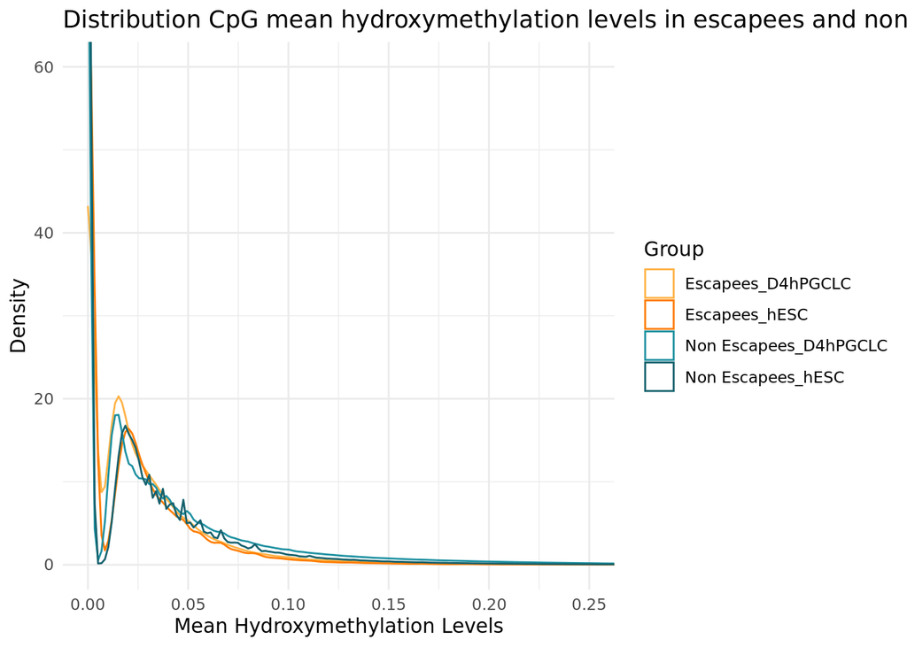

```r
# Create a new combined variable in the dataframe
MeanHydroxyMethLevels_df$GroupLabel <- paste(MeanHydroxyMethLevels_df$Category, MeanHydroxyMethLevels_df$Type, sep = "_")

# Now plot using this combined label
ggplot(MeanHydroxyMethLevels_df, aes(x = MeanHydroxyMeth, color = GroupLabel, group = GroupLabel)) +
  geom_density(alpha = 0.6, adjust = 1.5) +  # smoother curves using `adjust`
  labs(
    title = "Distribution CpG mean hydroxymethylation levels in escapees and non-escapees regions",
    x = "Mean Hydroxymethylation Levels",
    y = "Density",
    color = "Group"
  ) +
  scale_color_manual(
    values = c(
      "Escapees_hESC" = "#FF7D00",
      "Escapees_D4hPGCLC" = "#FFB347",
      "Non Escapees_hESC" = "#15616D",
      "Non Escapees_D4hPGCLC" = "#1E91A1"
    )
  ) +
  coord_cartesian(xlim = c(0, 0.25), ylim = c(0, 60)) +  # cut off at y = 6
  theme_minimal()
```

# 5.Session Info

```r
date()
## [1] "Wed Jul  9 13:15:31 2025"
sessionInfo()
## R version 4.2.1 (2022-06-23)
## Platform: x86_64-pc-linux-gnu (64-bit)
## Running under: Ubuntu 20.04.4 LTS
##
## Matrix products: default
## BLAS:   /usr/lib/x86_64-linux-gnu/blas/libblas.so.3.9.0
## LAPACK: /usr/lib/x86_64-linux-gnu/lapack/liblapack.so.3.9.0
##
## locale:
##  [1] LC_CTYPE=en_US.UTF-8       LC_NUMERIC=C
##  [3] LC_TIME=en_US.UTF-8        LC_COLLATE=en_US.UTF-8
##  [5] LC_MONETARY=en_US.UTF-8    LC_MESSAGES=en_US.UTF-8
##  [7] LC_PAPER=en_US.UTF-8       LC_NAME=C
##  [9] LC_ADDRESS=C               LC_TELEPHONE=C
## [11] LC_MEASUREMENT=en_US.UTF-8 LC_IDENTIFICATION=C
##
## attached base packages:
## [1] stats4    stats     graphics  grDevices utils     datasets  methods
## [8] base
##
## other attached packages:
##  [1] tidyr_1.3.0                 ggplot2_3.4.2
##  [3] dmrseq_1.18.1               bsseq_1.34.0
##  [5] SummarizedExperiment_1.28.0 Biobase_2.58.0
##  [7] MatrixGenerics_1.10.0       matrixStats_1.0.0
##  [9] GenomicRanges_1.50.2        GenomeInfoDb_1.34.9
## [11] IRanges_2.32.0              S4Vectors_0.36.2
## [13] BiocGenerics_0.44.0         dplyr_1.1.2
## [15] plyr_1.8.8
##
## loaded via a namespace (and not attached):
##   [1] AnnotationHub_3.6.0           BiocFileCache_2.6.1
##   [3] splines_4.2.1                 BiocParallel_1.32.6
##   [5] digest_0.6.33                 foreach_1.5.2
##   [7] htmltools_0.5.5               fansi_1.0.4
##   [9] magrittr_2.0.3                memoise_2.0.1
##  [11] BSgenome_1.66.3               tzdb_0.4.0
##  [13] limma_3.54.2                  Biostrings_2.66.0
##  [15] readr_2.1.4                   R.utils_2.12.2
##  [17] prettyunits_1.1.1             colorspace_2.1-0
##  [19] blob_1.2.4                    rappdirs_0.3.3
##  [21] xfun_0.39                     crayon_1.5.2
##  [23] RCurl_1.98-1.12               jsonlite_1.8.7
##  [25] annotatr_1.24.0               iterators_1.0.14
##  [27] glue_1.6.2                    gtable_0.3.3
##  [29] zlibbioc_1.44.0               XVector_0.38.0
##  [31] DelayedArray_0.24.0           Rhdf5lib_1.20.0
##  [33] HDF5Array_1.26.0              scales_1.2.1
##  [35] DBI_1.1.3                     rngtools_1.5.2
##  [37] Rcpp_1.0.11                   xtable_1.8-4
##  [39] progress_1.2.2                bumphunter_1.40.0
##  [41] bit_4.0.5                     httr_1.4.6
##  [43] RColorBrewer_1.1-3            ellipsis_0.3.2
##  [45] pkgconfig_2.0.3               XML_3.99-0.14
##  [47] R.methodsS3_1.8.2             farver_2.1.1
##  [49] sass_0.4.7                    dbplyr_2.3.3
##  [51] locfit_1.5-9.7                utf8_1.2.3
##  [53] tidyselect_1.2.0              labeling_0.4.2
##  [55] rlang_1.1.1                   reshape2_1.4.4
##  [57] later_1.3.1                   AnnotationDbi_1.60.2
##  [59] munsell_0.5.0                 BiocVersion_3.16.0
##  [61] tools_4.2.1                   cachem_1.0.8
##  [63] cli_3.6.1                     generics_0.1.3
##  [65] RSQLite_2.3.1                 evaluate_0.21
##  [67] stringr_1.5.0                 fastmap_1.1.1
##  [69] yaml_2.3.7                    outliers_0.15
##  [71] knitr_1.43                    bit64_4.0.5
##  [73] purrr_1.0.1                   KEGGREST_1.38.0
##  [75] nlme_3.1-162                  doRNG_1.8.6
##  [77] sparseMatrixStats_1.10.0      mime_0.12
##  [79] R.oo_1.25.0                   xml2_1.3.5
##  [81] biomaRt_2.54.1                compiler_4.2.1
##  [83] rstudioapi_0.15.0             filelock_1.0.2
##  [85] curl_5.0.1                    png_0.1-8
##  [87] interactiveDisplayBase_1.36.0 tibble_3.2.1
##  [89] bslib_0.5.0                   stringi_1.7.12
##  [91] highr_0.10                    GenomicFeatures_1.50.4
##  [93] lattice_0.21-8                Matrix_1.6-0
##  [95] permute_0.9-7                 vctrs_0.6.3
##  [97] pillar_1.9.0                  lifecycle_1.0.3
##  [99] rhdf5filters_1.10.1           BiocManager_1.30.20
## [101] jquerylib_0.1.4               data.table_1.14.8
## [103] bitops_1.0-7                  httpuv_1.6.11
## [105] rtracklayer_1.58.0            R6_2.5.1
## [107] BiocIO_1.8.0                  promises_1.2.0.1
## [109] codetools_0.2-19              gtools_3.9.4
## [111] rhdf5_2.42.1                  rjson_0.2.21
## [113] withr_2.5.0                   regioneR_1.30.0
## [115] GenomicAlignments_1.34.1      Rsamtools_2.14.0
## [117] GenomeInfoDbData_1.2.9        parallel_4.2.1
## [119] hms_1.1.3                     grid_4.2.1
## [121] rmarkdown_2.23                DelayedMatrixStats_1.20.0
## [123] shiny_1.7.4.1                 restfulr_0.0.15
```